# Übungsklausur

## Matrikel-Nr.: (Bitte eintragen!)

## Platz: (Bitte eintragen!)

#### Bitte beachten:

- Alle Lösungen sind IN das Rmarkdown File zu schreiben.
- Lese genau, wonach gefragt wird und wie die Lösung anzugeben ist.
- Für jede Aufgabe ist die maximal zu erreichende Punktzahl gegeben.

#### Zugelassene Hilfsmittel:

- Ein (auch beidseitig) handschriftlich beschriebenes DIN A4-Blatt.

#### Anzahl der anzugebenden Lösungen

- Gebe niemals mehrere Lösungsalternativen an. Es wird sonst die erste Antwort genommen.

## Anzahl der Aufgaben: 3 (in echter Klausur 4)

## Gesamtpunktzahl: 50

# Aufgabe 1 (12 Punkte):

Im folgenden werden Aussagen getroffen welche entweder WAHR oder FALSCH sind. Bewerte jede Aussage, treffe eine Entscheidung ob diese WAHR oder FALSCH ist. Wenn die Aussage FALSCH ist, bitte begründe warum.

Jede richtig beantwortete Aufgabe gibt 2 Punkte.

*Beispiel:* Wahr oder Falsch?

Im Model $y_1 = \alpha + \gamma x_1 + \zeta_1$ $y_1$ steht dafür, dass es nur eine Beobachtung gibt.

**Antwort:** Falsch. Die $1$ in dem Modell steht jeweils für die erste Variable $y$. Wir können in SEM Modellen mehrere $y$-Variablen haben.

1. Der Satz von Bayes berechnet die Wahrscheinlichkeit davon, dass zwei Ereignisse $A$ und $B$ gleichzeitig auftreten. (2 Punkte)

**Antwort:** Falsch. Der Satz von Bayes berechnet bedingte Wahrscheinlichkeiten, also der Wahrscheinlichkeit dass z.B. A eintritt, wenn B bereits eingetreten ist.

2. Du machst zwei Würfelwürfe (Ereignisse $A$ und $B$). Beim ersten Wurf $A$ sind sechs Augen zu sehen, nun ist die marginale Wahrscheinlichkeit für sechs Augen beim zweiten Wurf $1/36$. (2 Punkte)

**Antwort:** Falsch. Marginale Wahrscheinlichkeiten sind unabhängig von anderen Ergebnissen. Die Marginale Wahrscheinlichkeit für den zweiten Wurf, ist also nur die Wahrscheinlichkeit von von zweiten alleine also $1/6$.

3. Wahrscheinlichkeiten können nur Werte zwischen $0$ und $1$ annehmen. (2 Punkte)

**Antwort:** Wahr.

4. Es gibt keine Unterschiede in den Ergebnissen von Kleinst-Quadrate und Maximum-Likelihood Schätzung eines Modells. (2 Punkte)

**Antwort:** Falsch. Die Schätzer der Varianz vom KQ und ML Ansatz unterscheiden sich.

5. Bei bayesianischen Modellen wollen wir die Posterior Verteilung berechnen. (2 Punkte)

**Antwort:** Wahr.

6. Strukturgleichungsmodelle sind speziell, denn sie erlauben es als einziges Modellframework Regression durchzuführen. (2 Punkte)

**Antwort:** Falsch. Auch Lineare Regressionsmodelle oder bayesianische Modelle erlauben ebenfalls eine Regression.

# Aufgabe 2: Bayesianisches Modell (20 Punkte)

*Setup:*

```r
library(brms)
set.seed(42)
```

```r
# Erste Möglichkeit
library(readr)
datensatz1 <- read_csv("datensatz1.csv")
# Zweite Möglichkeit
datensatz1 <- read.csv("datensatz1.csv")
```

*Hinweis:* Wie bei vielem in R gibt es verschiedene Lösungsmöglichkeiten.

2. Schaue dir die zu erklärende Variable `y` an. Welche Verteilung folgt diese? Was bedeutet es für ein bayesianisches Modell? (2 Punkte)

```r
summary(datensatz1$y)
```

```
##    Min. 1st Qu.  Median    Mean 3rd Qu.    Max.
##   387.4   585.0   661.6   675.7   774.2  1006.7
```

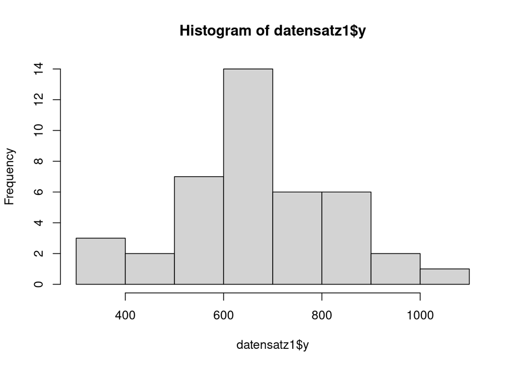

```r
hist(datensatz1$y)
```

**Antwort:** Die Variablen `y` scheint einer Normalverteilung zu folgen, auch wenn dies natürlich nicht perfekt aussieht. Aber wir haben ja nur 41 Beobachtungen, also weit weg von “optimalen” Umständen. Es macht Sinn eine Normalverteilung für die “Family” der Daten in einem Bayesianischen Modell zu unterstellen.

3. Gegeben der Daten baue ein einfaches bayesianisches Modell, welche die Variablen `x1`, `x2` und einen Intercept nutzt um `y` zu erklären. Hierbei nimm an, dass du kein eigenes Wissen über die Daten hast. Wie würdest du die Prior auswählen? Begründe deine Entscheidungen. (8 Punkte)

```r
summary(datensatz1)
```

```
##        x1              x2               y
##  Min.   :0.000   Min.   :-402.3   Min.   : 387.4
##  1st Qu.:1.000   1st Qu.:  13.1   1st Qu.: 585.0
##  Median :2.000   Median : 114.1   Median : 661.6
##  Mean   :2.439   Mean   : 125.3   Mean   : 675.7
##  3rd Qu.:4.000   3rd Qu.: 241.3   3rd Qu.: 774.2
##  Max.   :5.000   Max.   : 556.2   Max.   :1006.7
```

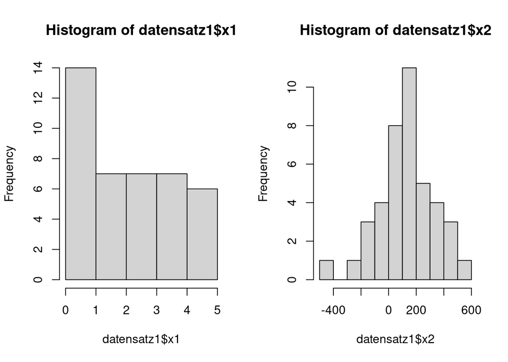

```r
# Verteilung der Variablen X1 und X2
par(mfrow=c(1,2))
hist(datensatz1$x1); hist(datensatz1$x2)
```

```r
# Das Modell:
model_c <- brm(y ~ 1 + x1 + x2,
                 data = datensatz1,
                 family = gaussian(),
                 prior = c(
                   prior(normal(675, 150), class = Intercept),
                   prior(normal(0, 150), class = sigma),
                   prior(normal(2.5, 1.8),  class = b, coef = x1),
                   prior(normal(125, 200), class = b, coef = x2)
                 ),
               cores = 10,
               control = list(adapt_delta = 0.9),
               save_pars = save_pars(all = TRUE)
            )
summary(model_c)
```

```
##  Family: gaussian
##   Links: mu = identity; sigma = identity
## Formula: y ~ 1 + x1 + x2
##    Data: datensatz1 (Number of observations: 41)
##   Draws: 4 chains, each with iter = 2000; warmup = 1000; thin = 1;
##          total post-warmup draws = 4000
##
## Population-Level Effects:
##           Estimate Est.Error l-95% CI u-95% CI Rhat Bulk_ESS Tail_ESS
## Intercept   660.00     27.49   605.29   713.59 1.00     4502     2731
## x1            2.87      1.75    -0.52     6.31 1.00     4713     2721
## x2            0.07      0.12    -0.16     0.30 1.00     5146     3036
##
## Family Specific Parameters:
##       Estimate Est.Error l-95% CI u-95% CI Rhat Bulk_ESS Tail_ESS
## sigma   150.82     17.05   121.88   187.10 1.00     3787     2840
##
## Draws were sampled using sampling(NUTS). For each parameter, Bulk_ESS
## and Tail_ESS are effective sample size measures, and Rhat is the potential
## scale reduction factor on split chains (at convergence, Rhat = 1).
```

**Antwort:**

- Intercept: Ist der Schwerpunkt (Mittelwert) der Daten, welcher bei 675 liegt. Die Std. davon stellt einfach unsere Unsicherheit dar.
- sigma : Ist die Modellstd. welche wir aus den Daten approximieren können über `sd()`, welche bei 150 liegt. Der Mittelwert von sigma liegt per Modell Annahmen immer bei 0.
- x1 : Scheint mehr oder minder gleichverteilt zu sein (alternativ könnte man hier auch Mittelwert zentrieren was die Form auch verändert). Unteregrenze liegt bei 0 und obere bei 5.
4. Ist das Modell konvergiert? Begründe.

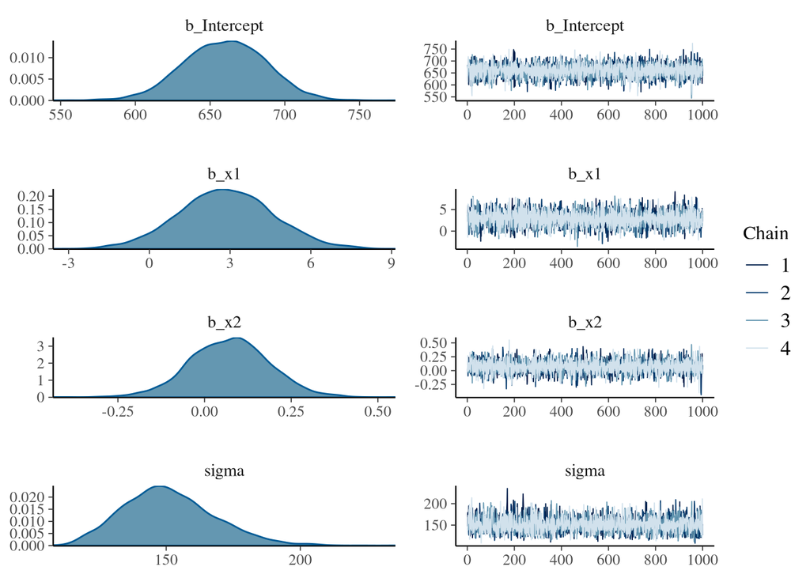

```r
plot(model_c)
```

**Antwort:** Am Plot kann man sehen, dass die Graphen (rechts) übereinander liegen spricht es dafür, dass das Modell “fertig” konvergiert sind. Alternativ kann man es an der `summary()` erkennen, so wie es am Ende steht mit `Rhat is the potential ## scale reduction factor on split chains (at convergence, Rhat = 1).` Also Rhat = 1 es ist konvergiert, was man auch hier erkennen kann.

5. Nach betrachten der Daten behauptet einer deiner Kommilitonen, dass die Variable `x2` keinerlei Einfluss auf `y` haben sollte. Untersuche ob Variable `x2` ein Platz im Modell haben sollte oder nicht. Begründe. (4 Punkte)

```r
model_e <- brm(y ~ 1 + x1,
                 data = datensatz1,
                 family = gaussian(),
                 prior = c(
                   prior(normal(675, 150), class = Intercept),
                   prior(normal(0, 150), class = sigma),
                   prior(normal(2.5, 1.8),  class = b, coef = x1)
                 ),
               cores = 10,
               control = list(adapt_delta = 0.9),
               save_pars = save_pars(all = TRUE)
            )
# Bayes Faktor
margLogLik_m1 <- bridge_sampler(model_c, silent = TRUE)
margLogLik_m2 <- bridge_sampler(model_e, silent = TRUE)
(BF_ln <- bayes_factor(margLogLik_m1, margLogLik_m2))
```

[output not shown]

```r
WAIC(model_c, model_e)
```

```
## Output of model 'model_c':
##
## Computed from 4000 by 41 log-likelihood matrix
##
##           Estimate  SE
## elpd_waic   -265.1 4.2
## p_waic         2.8 0.5
## waic         530.3 8.4
##
## Output of model 'model_e':
##
## Computed from 4000 by 41 log-likelihood matrix
##
##           Estimate  SE
## elpd_waic   -265.2 4.2
## p_waic         2.9 0.6
## waic         530.4 8.4
##
## Model comparisons:
##         elpd_diff se_diff
## model_c  0.0       0.0
## model_e -0.1       0.1
```

**Antwort:** Wir können erkennen, dass das zweite Modell um `0.1` Punkte schlechter ist. Also eine absolute minimale Verschlechterung. Jetzt kann man streng argumentieren, dass das schlechter ist und somit das erste Modell besser ist . Man kann aber auch argumentieren, dass durch das weglassen von einer ganzen Variablen der Wert sich um einen absolut geringen Wert von `0.1` verschlechtert. Es könnte man auch so interepretieren, dass somit die die Variable nicht wichtig ist. Beides verständliche Argumentationen. (In einer Klausur kommt es auf DEINE Interpretation an!)

6. Interpretiere die Ergebnisse für die Schätzer der Parameter des Modells was du in (d) ausgewählt hast. (3 Punkte)

```r
# Sagen wir mal, dass das erste Modell besser ist
summary(model_c)
```

```
##  Family: gaussian
##   Links: mu = identity; sigma = identity
## Formula: y ~ 1 + x1 + x2
##    Data: datensatz1 (Number of observations: 41)
##   Draws: 4 chains, each with iter = 2000; warmup = 1000; thin = 1;
##          total post-warmup draws = 4000
##
## Population-Level Effects:
##           Estimate Est.Error l-95% CI u-95% CI Rhat Bulk_ESS Tail_ESS
## Intercept   660.00     27.49   605.29   713.59 1.00     4502     2731
## x1            2.87      1.75    -0.52     6.31 1.00     4713     2721
## x2            0.07      0.12    -0.16     0.30 1.00     5146     3036
##
## Family Specific Parameters:
##       Estimate Est.Error l-95% CI u-95% CI Rhat Bulk_ESS Tail_ESS
## sigma   150.82     17.05   121.88   187.10 1.00     3787     2840
##
## Draws were sampled using sampling(NUTS). For each parameter, Bulk_ESS
## and Tail_ESS are effective sample size measures, and Rhat is the potential
## scale reduction factor on split chains (at convergence, Rhat = 1).
```

# Aufgabe 3: Strukturgleichungsmodelle (18 Punkte)

```r
library(lavaan)
```

1. Lese den Datensatz `datensatz2.csv` ein. (1 Punkt)

```r
# Erste Möglichkeit
library(readr)
datensatz2 <- read_csv("datensatz2.csv")
# Zweite Möglichkeit
datensatz2 <- read.csv("datensatz2.csv")
```

```r
m_gleichung <- '# measurement
                f1 =~ x1 + x2 + x3 + x4 + x5
                f2 =~ x6 + x7'
m_b <- sem(m_gleichung, data=datensatz2)
```

3. Nutze die beiden erstellten latenten Variablen aus (b) um das unterstellte `y` zu erklären. Kommt das selbe Ergebnis dabei raus, wenn du statt den latenten Varialben direkt $x_1, x_2, x_3, x_4, x_5, x_6, x_7$ nutzt ? Begründe. (4 Punkte)

```r
m_gleichung <- '#regression
                y ~ f1+ f2
                #measurement
                f1 =~ x1 + x2 + x3 + x4 + x5
                f2 =~ x6 + x7'
m_c <- sem(m_gleichung, data=datensatz2)
```

**Antwort:** Nein, es wird nicht das gleiche Modell (Ergebnis) dabei herauskommen, da das Measurement Modell eine Form der Faktoranalyse macht, und die X Variablen nicht zu 100 genutzt werden. Beispiel: Wenn wir das reine $x$ Model bauen, und annahmen dass beide Modelle gleich sind, dann müssten beide Modelle die selben Werte z.B. AIC aufweisen. Wie hier zu sehen ist dem nicht so (auch wenn das mOdell nicht fertig konvergiert … nun.)

```r
m_gleichung <- '#regression
                y ~ x1 + x2 + x3 + x4 + x5 + x6 + x7
                #measurement
                f1 =~ x1 + x2 + x3 + x4 + x5
                f2 =~ x6 + x7'
m_c2 <- sem(m_gleichung, data=datensatz2)
AIC(m_c, m_c2)
```

```
##      df      AIC
## m_c  18 4209.708
## m_c2 23 4214.227
```

4. Erstelle das selbe Modell noch einmal, nur unterstelle jetzt, dass es eine implizite Covarianz/Correlation zwischen $x_4$ und $x_6$ gibt. Baue diese in das neue Modell ein. Vergleiche das Model aus (c) und aus (d), welches dieser Modelle schätzt du als besser geeignet ein? (9 Punkte)

```r
m_gleichung <- '#structural
                y ~ f1+ f2
                #measurement
                f1 =~ x1 + x2 + x3 + x4 + x5
                f2 =~ x6 + x7
                #correlation
                x6 ~~ x4
                '
m_d <- sem(m_gleichung, datensatz2)
```

```r
summary(m_c, fit.measures = TRUE)
```

```
## lavaan 0.6.15 ended normally after 34 iterations
##
##   Estimator                                         ML
##   Optimization method                           NLMINB
##   Number of model parameters                        18
##
##   Number of observations                           200
##
## Model Test User Model:
##
##   Test statistic                                20.800
##   Degrees of freedom                                18
##   P-value (Chi-square)                           0.290
##
## Model Test Baseline Model:
##
##   Test statistic                               587.737
##   Degrees of freedom                                28
##   P-value                                        0.000
##
## User Model versus Baseline Model:
##
##   Comparative Fit Index (CFI)                    0.995
##   Tucker-Lewis Index (TLI)                       0.992
##
## Loglikelihood and Information Criteria:
##
##   Loglikelihood user model (H0)              -2086.854
##   Loglikelihood unrestricted model (H1)      -2076.454
##
##   Akaike (AIC)                                4209.708
##   Bayesian (BIC)                              4269.078
##   Sample-size adjusted Bayesian (SABIC)       4212.052
##
## Root Mean Square Error of Approximation:
##
##   RMSEA                                          0.028
##   90 Percent confidence interval - lower         0.000
##   90 Percent confidence interval - upper         0.071
##   P-value H_0: RMSEA <= 0.050                    0.754
```

[output cut: 32 more lines]

```
##   f1 ~~
##     f2                0.064    0.043    1.493    0.135
##
## Variances:
##                    Estimate  Std.Err  z-value  P(>|z|)
##    .x1                0.294    0.043    6.763    0.000
##    .x2                0.659    0.074    8.933    0.000
##    .x3                0.584    0.070    8.368    0.000
##    .x4                0.402    0.051    7.898    0.000
##    .x5                0.506    0.062    8.210    0.000
##    .x6                1.089    0.131    8.325    0.000
##    .x7                0.064    0.139    0.461    0.645
##    .y                 0.867    0.114    7.615    0.000
##     f1                0.591    0.089    6.612    0.000
##     f2                0.458    0.132    3.479    0.001
```

```r
summary(m_d, fit.measures = TRUE)
```

```
## lavaan 0.6.15 ended normally after 32 iterations
##
##   Estimator                                         ML
##   Optimization method                           NLMINB
##   Number of model parameters                        19
##
##   Number of observations                           200
##
## Model Test User Model:
##
##   Test statistic                                19.214
##   Degrees of freedom                                17
##   P-value (Chi-square)                           0.316
##
## Model Test Baseline Model:
##
##   Test statistic                               587.737
##   Degrees of freedom                                28
##   P-value                                        0.000
##
## User Model versus Baseline Model:
##
##   Comparative Fit Index (CFI)                    0.996
##   Tucker-Lewis Index (TLI)                       0.993
##
## Loglikelihood and Information Criteria:
##
##   Loglikelihood user model (H0)              -2086.061
##   Loglikelihood unrestricted model (H1)      -2076.454
##
##   Akaike (AIC)                                4210.122
##   Bayesian (BIC)                              4272.790
##   Sample-size adjusted Bayesian (SABIC)       4212.596
##
## Root Mean Square Error of Approximation:
##
##   RMSEA                                          0.026
##   90 Percent confidence interval - lower         0.000
##   90 Percent confidence interval - upper         0.071
##   P-value H_0: RMSEA <= 0.050                    0.766
```

[output cut: 34 more lines]

```
##   f1 ~~
##     f2                0.064    0.044    1.456    0.146
##
## Variances:
##                    Estimate  Std.Err  z-value  P(>|z|)
##    .x1                0.293    0.043    6.774    0.000
##    .x2                0.658    0.074    8.939    0.000
##    .x3                0.585    0.070    8.389    0.000
##    .x4                0.401    0.051    7.856    0.000
##    .x5                0.507    0.062    8.234    0.000
##    .x6                1.076    0.129    8.315    0.000
##    .x7                0.091    0.132    0.689    0.491
##    .y                 0.853    0.114    7.479    0.000
##     f1                0.592    0.089    6.626    0.000
##     f2                0.464    0.131    3.534    0.000
```

**Antwort:**

- Informationskriterien: Model (c) besser
- RMSEA : Model (d) besser
- SRMR: Model (c) besser
- CFI/TLI : Model (d) besser

Entscheidung: Wir können hier kein eindeutiges Ergebnis erkennen. Es kommt hierbei ganz klar auf eure Argumentation an. Ich persönlich würde mich für das Model aus c entscheiden, da hier ganze drei Informationskriterien für dieses Modell sprechen. Allerdings wäre eine Argumentation genauso richtig zu sagen, dass ein geringerer Fehler für ein besseres Modell sprich, was basierent auf dem RMSEA für das MOdel aus (d) spricht.